# How long do mappers spend accepting objects using RapID?

Inspired by questions on the `#mapwithai_feedback` channel on OpenStreetMap US Slack.

```python
import seaborn as sns
import pandas as pd
import datetime, sys
import matplotlib, statistics

%config InlineBackend.figure_format = 'retina'
%matplotlib inline
```

## First, pull all RapID changesets from Athena (using the AWS OSM Public Dataset)

```
SELECT   id, num_changes, created_at, "user", uid, CAST(tags AS JSON) AS tags,
         min_lon AS min_x, max_lon AS max_x, min_lat AS min_y, max_lat AS max_y
FROM     changesets
WHERE lower(tags['created_by']) LIKE 'rapid%'
ORDER BY created_at DESC
```

```python
df = pd.read_csv('/Users/jenningsanderson/Downloads/3c1469bc-f24c-46fb-976d-fc1cf6443fd1.csv')
df['date'] = df.created_at.apply(pd.Timestamp)
df['day'] = df.date.apply(pd.Timestamp.date)
print("Found {:,} changesets".format(len(df)))
df.head(2)
```

```
Found 226,617 changesets
```

|  | id | num_changes | created_at | user | uid | tags | min_x | max_x | min_y | max_y | date | day |
| --- | --- | --- | --- | --- | --- | --- | --- | --- | --- | --- | --- | --- |
| 0 | 87263606 | 6 | 2020-06-28 23:53:50.000 | George64593 | 11341653 | {"changesets_count":"7","comment":"#hotosm-pro... | 125.243097 | 125.243171 | 6.751084 | 6.751185 | 2020-06-28 23:53:50 | 2020-06-28 |
| 1 | 87263587 | 13 | 2020-06-28 23:51:21.000 | Camello_AR | 657643 | {"changesets_count":"6978","comment":"Relación... | -59.891294 | -59.884678 | -36.795268 | -36.788481 | 2020-06-28 23:51:21 | 2020-06-28 |

```python
print("Top 10 RapID editors:")
df.user.value_counts().head(10)
```

```
Top 10 RapID editors:
```

```
maning             7527
VLD150             5477
Yagni              4374
jedimasterflint    4273
Mel_1              3881
Arma IRM-ED        3748
VLD151             3744
VLD154             3570
Cinderblock        3171
VLD089             3127
Name: user, dtype: int64
```

Not a surprise: mostly Facebook (`VLD*`) and Kaart editors.

# General Overview of RapID Adoption

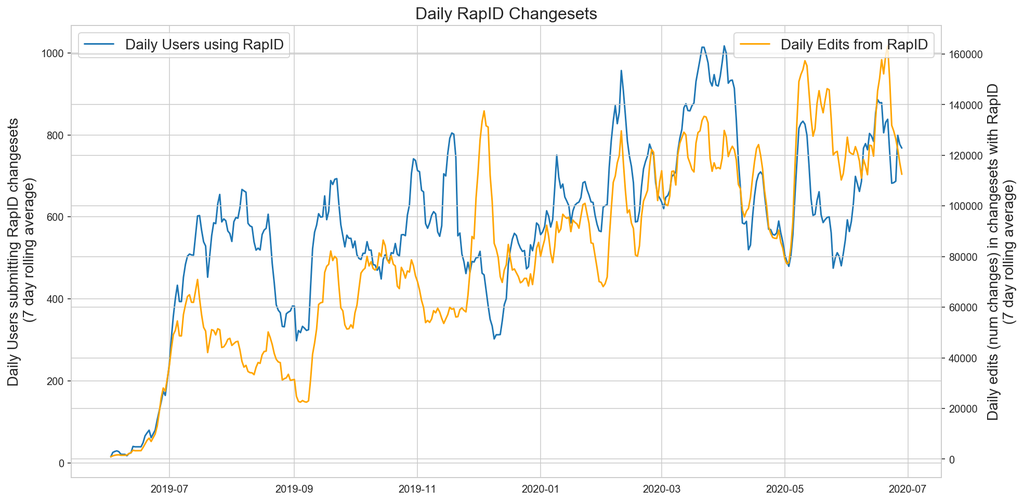

```python
sns.set_style("whitegrid")
gb_day = df.groupby('day').aggregate({'num_changes':sum,'uid':'count'})
ax = gb_day.uid.rolling(7).mean().plot(figsize=(15,8))
ax2 = gb_day.num_changes.rolling(7).mean().plot(ax=ax.twinx(), color='orange')

ax.legend(['Daily Users using RapID'], loc="upper left", fontsize=14)
ax2.legend(['Daily Edits from RapID'], loc="upper right", fontsize=14)
ax.set_ylabel("Daily Users submitting RapID changesets\n (7 day rolling average)", fontsize=14)
ax2.set_ylabel("Daily edits (num changes) in changesets with RapID\n(7 day rolling average)", fontsize=14);
ax.set_xlabel(""); ax.set_title("Daily RapID Changesets", fontsize=16);
```

# What about long-term adoption of RapID?

When did people start using RapID and how long have they kept with it?

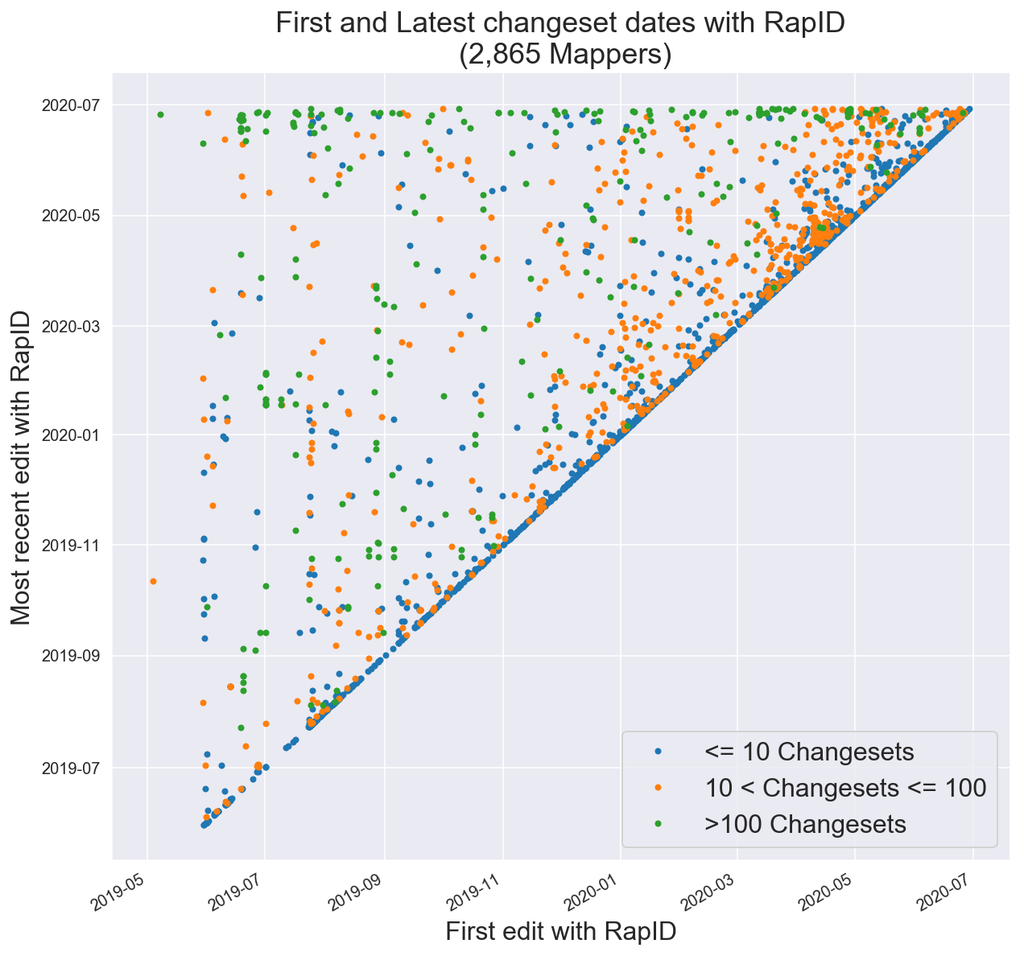

```python
sns.set_style('darkgrid'); figsize=(8,8)
gb_uid = df.groupby("uid").aggregate({'date':[min,max],'id':'count'})
gb_uid.columns = ['first_rapid','latest_rapid','changesets']
ax = gb_uid[gb_uid.changesets <= 10].plot(x='first_rapid',y='latest_rapid', style=".", figsize=figsize, legend=None)
gb_uid[(gb_uid.changesets > 10) & (gb_uid.changesets <=100)].plot(x='first_rapid',y='latest_rapid', style=".", figsize=(10,10), ax=ax, legend=None)
gb_uid[gb_uid.changesets > 100].plot(x='first_rapid',y='latest_rapid', style=".", figsize=(10,10), ax=ax, legend=None)

ax.legend(['<= 10 Changesets','10 < Changesets <= 100', '>100 Changesets'], fontsize=16)
ax.set_xlabel("First edit with RapID", fontsize=16); ax.set_ylabel("Most recent edit with RapID", fontsize=16)
ax.set_title("First and Latest changeset dates with RapID\n ({:,} Mappers)".format(len(gb_uid)), fontsize=18);
```

## How long do users spend on each object when using RapID?

How this is calculated:

1. We only have `created_at` date because of how iD editor works, the `created_at` and `closed_at` dates do not necessarily correspond to an editing session the way they do in JOSM (in my understanding).

### Psuedocode:

1. For each user, group their edits by day.
2. For each day a user edits, if they submit two changesets within `10 minutes` of each other, we assume that they are engaging in a RapID editing session and *saving* frequently, giving us something to measure.
   1. Calculate the time delta between the two `created_at` dates.
   2. Create assumption that `5 changes` to the OSM database equates to `1 object`. This is a major assumption, but it's based on the idea that the average building is `4 nodes + 1 way = 5 edits`; and that an average highway object may also have `4 nodes within 1 way = 5 edits`. It's not foolproof, but it's reasonable.
   3. If a changeset has more than `1 object`, create a `seconds-per-object` value: `time between two changesets / (edits in changeset / 5)`
   4. Store list of secondsPerObject values for each user.

```python
DEBUG = 0
THRESHOLD_BETWEEN_CHANGESETS = pd.Timedelta(minutes=10).total_seconds()

results = []

count = 1;
#First, group by users
for u, edits in df.groupby('uid'):
    entry = {
        'uid':u,
        'user':edits.user.values[0],
        'changesets':len(edits),
    }
    sys.stderr.write("\r{} -- {} ({}) has {:,} RapID changesets:                        ".format(count, u, edits.user.values[0], len(edits)))
    if DEBUG > 0:

        print("{} ({}) has {:,} RapID changesets: ".format(u, edits.user.values[0], len(edits)))

    #Now group a users edits by individual day:
    edits_per_day = edits.sort_values(by='date').groupby('day').aggregate({'id':'count','date':list,'num_changes':list})

    entry['days_editing'] = len(edits_per_day)
    entry['all_deltas'] = []

    #Now go through each of these days
    for day, daily_edits in edits_per_day.iterrows():
        if daily_edits.id > 1:
            if DEBUG > 1:
                print("Day: {} with {} edits: ".format(day, daily_edits.id))

            for idx, time in enumerate(daily_edits.date):

                if DEBUG > 2:
                    print(idx, time, daily_edits.num_changes[idx])

                if idx>0:

                    delta = (time - prev_time).total_seconds()
                    editCount = daily_edits.num_changes[idx]
                    objectCount = editCount / 5

                    if delta < THRESHOLD_BETWEEN_CHANGESETS:

                        if objectCount > 1:

                            secondsPerObject = delta / objectCount

                            entry['all_deltas'].append(secondsPerObject)

                        if DEBUG > 3:
                            print("\t", secondsPerObject, delta, editCount, objectCount)

                prev_time = time;
    if len(entry['all_deltas'])>0:
        results.append(entry)

    count+=1

deltas = pd.DataFrame(results)
```

```
2865 -- 11398355 (vvld21256) has 11 RapID changesets:
```

```python
sorted_deltas = deltas.sort_values(by='changesets',ascending=False).reindex()
sorted_deltas.head()
```

|  | all_deltas | changesets | days_editing | uid | user |
| --- | --- | --- | --- | --- | --- |
| 3 | [79.58333333333334, 56.66666666666667, 105.555... | 7527 | 168 | 1417 | maning |
| 825 | [206.66666666666669, 97.60869565217392, 216.66... | 5477 | 141 | 10197916 | VLD150 |
| 796 | [23.166666666666668, 9.67741935483871, 36.25, ... | 4374 | 32 | 10155906 | Yagni |
| 630 | [7.735849056603774, 8.965517241379311, 7.56838... | 4273 | 31 | 9218955 | jedimasterflint |
| 663 | [22.846153846153847, 172.0, 187.3076923076923,... | 3881 | 26 | 9395604 | Mel_1 |

### Plot the distributions of the `secondsPerObject` values:

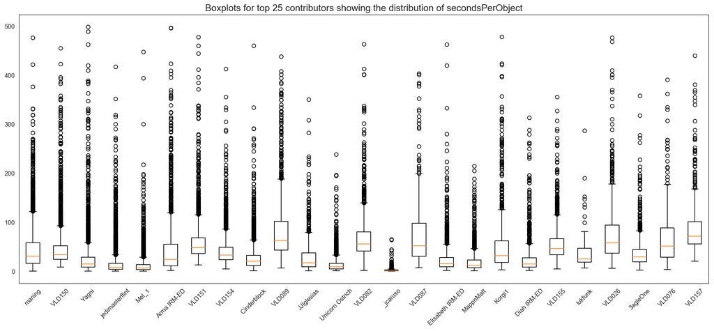

```python
sns.set_style('white')
topN = 25
fig, ax = matplotlib.pyplot.subplots()
fig.set_size_inches(20,8)
res = ax.boxplot(sorted_deltas.head(topN).all_deltas,
                 labels=sorted_deltas.user.head(topN))
matplotlib.pyplot.xticks(rotation=45);

ax.set_title("Boxplots for top 25 contributors showing the distribution of secondsPerObject", fontsize=15);
```

This seems reasonable. The outliers are a bit noisy, turn those off and change the y-scale to `log` so that we can see what's happening within the 10-100 second range:

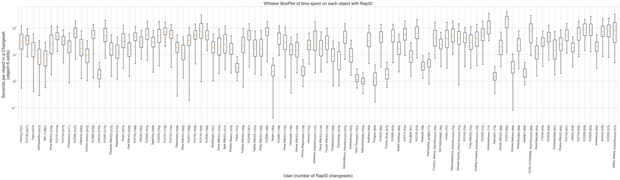

```python
sns.set_style('whitegrid')
topN = 100
fig, ax = matplotlib.pyplot.subplots()
fig.set_size_inches(40,8)
res = ax.boxplot(sorted_deltas.head(topN).all_deltas,
                 labels=sorted_deltas.head(topN).apply(lambda row: row.user +
                        " ("+str(row.changesets)+")",axis=1), showfliers=False)
matplotlib.pyplot.xticks(rotation=88);
ax.set_yscale('log')

ax.set_xlabel("User (number of RapID changesets)", fontsize=16);
ax.set_ylabel("Seconds per object in a Changeset\n(object=5 edits)", fontsize=16);
ax.set_title("Whisker BoxPlot of time spent on each object with RapID", fontsize=16);
```

Interesting. It looks like there are definitely *some* users that spend under a second on each object, but generally it's actualy more than 10 seconds, but less than 100 seconds per object? Let's look more closely at the median:

```python
sorted_deltas['median'] = sorted_deltas.all_deltas.apply(lambda x: statistics.median(x))
sorted_deltas.head()
```

|  | all_deltas | changesets | days_editing | uid | user | median |
| --- | --- | --- | --- | --- | --- | --- |
| 3 | [79.58333333333334, 56.66666666666667, 105.555... | 7527 | 168 | 1417 | maning | 30.833333 |
| 825 | [206.66666666666669, 97.60869565217392, 216.66... | 5477 | 141 | 10197916 | VLD150 | 33.970588 |
| 796 | [23.166666666666668, 9.67741935483871, 36.25, ... | 4374 | 32 | 10155906 | Yagni | 14.666667 |
| 630 | [7.735849056603774, 8.965517241379311, 7.56838... | 4273 | 31 | 9218955 | jedimasterflint | 7.777778 |
| 663 | [22.846153846153847, 172.0, 187.3076923076923,... | 3881 | 26 | 9395604 | Mel_1 | 6.585366 |

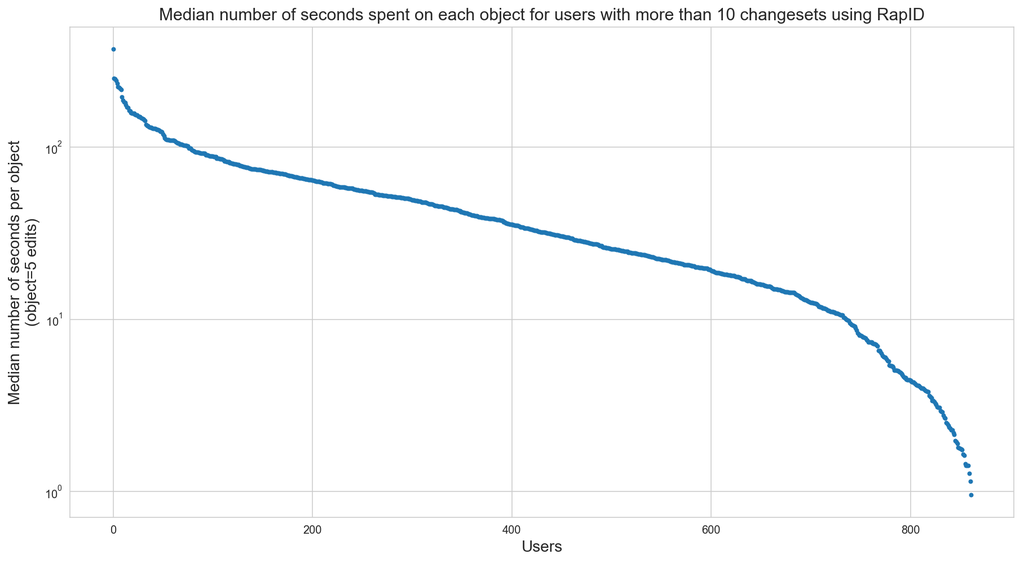

```python
sns.set_style("whitegrid")
ax = sorted_deltas[sorted_deltas.changesets > 10].sort_values(by='median',ascending=False).reset_index()['median'].plot(
    figsize=(15,8), style=".")

ax.set_xlabel("Users", fontsize=14); ax.set_ylabel("Median number of seconds per object\n(object=5 edits)", fontsize=14)
ax.set_title("Median number of seconds spent on each object for users with more than 10 changesets using RapID",fontsize=15);
ax.set_yscale('log')
```

For users with more than 10 RapID changesets, this is the breakdown (max -> min) of the median seconds spent editing each `object` in which an `object` corresponds to `5 changes` as counted from the `num_changes` attribute.